# Spark

Navaro Pierre, Sophie Donnet, Pierre Barbillon, Martina Sundqvist, Timothée Tabouy

28/08/2019

## Sparklyr : gestion des gros jeux de données.

R studio gère entièrement l’installation de spark (librairie qui permet de gérer des taches) et sparklyr (package R qui permet d’utiliser un cluster spark). Pour ceci il suffit d’aller dans environnement -> new environnement -> spark. Une fois ceci fait on a crée un cluster spark (local dans ce cas-ci, en changeant l’option master il peut ne pas être local). EN local, il crée une collection parralèle en découpant tes données sur un nombre de coeur spécifié au moment de la création de la connection sur Rstudio en écrivant

```r
library(sparklyr)
library(dplyr)
sc <- spark_connect(master = "local")
```

Ceci peut être fait pas presse-boutons depuis Rstudio. Il est possible de spécifier le nombre de coeurs en utilisant la commande suivante:

```r
sc <- spark_connect(master = "local[4]")
```

pour 4 coeurs.

Si les données sont sur un serveur, on y accède en remplaçant local par l’adresse du serveur.

En cliquant sur l’onglet Spark on a accès automatiquement à une interface web qui contient toutes les taches effectuées sur le cluster spark. Cette peut-être partagé, si les données sont sur un cluster, entre plusieurs personnes.

Remarque : il existe un toturiel ici https://spark.rstudio.com/, nous l’avons suivi en commençant à la section “Using dplyr” car spark et sparklyr ont été installé par la manipulation précédente.

L’intérêt d’utiliser le serveur spark est d’avoir accès à des fonctions parrallélisées et puissantes pour gérer les grosses données.

Sont mis à disposition les fonctions du package dplyr, on peut aussi exécuter des requêtes SQL, faire du machine learning avec sparklyr (voir https://spark.rstudio.com/mlib/ pour une liste complète des fonctions à disposition).

## Les données avec Spark

L’objet `sc` est en gros l’adresse du cluster spark. C’est un objet de type `list`.

On va maintenant chercher à envoyer des données vers le serveur. Pour notre cas, nous allons utiliser des données contenues dans les packages suivants:

```r
########### packages de données
library("nycflights13")
library("Lahman")
library(dplyr)
```

Pour les envoyer dans le `sc`, nous utilisons la commande `copy_to`.

```r
iris_tbl <- copy_to(sc, iris) # on copie les données
```

Les données `iris`n’apparaissent pas dans l’environnement Rstudio. L’objet `iris_tbl` est une liste contenant *en gros* l’adresse des données sur le sc.

```r
names(iris_tbl)
```

```
## [1] "src" "ops"
```

```r
iris_tbl$src
```

```
## spark connection master=local[4] app=sparklyr local=TRUE
```

```r
iris_tbl$ops
```

```
## From: iris
## <Table: iris>
```

On peut afficher les données. On obtient alors un aperçu de la table dans lequel il est spécifié que c’est un objet spark.

```r
iris_tbl
```

```
## # Source: spark<iris> [?? x 5]
##    Sepal_Length Sepal_Width Petal_Length Petal_Width Species
##           <dbl>       <dbl>        <dbl>       <dbl> <chr>
##  1          5.1         3.5          1.4         0.2 setosa
##  2          4.9         3            1.4         0.2 setosa
##  3          4.7         3.2          1.3         0.2 setosa
##  4          4.6         3.1          1.5         0.2 setosa
##  5          5           3.6          1.4         0.2 setosa
##  6          5.4         3.9          1.7         0.4 setosa
##  7          4.6         3.4          1.4         0.3 setosa
##  8          5           3.4          1.5         0.2 setosa
##  9          4.4         2.9          1.4         0.2 setosa
## 10          4.9         3.1          1.5         0.1 setosa
## # ... with more rows
```

```r
flights_tbl <- copy_to(sc, nycflights13::flights, "flights")
batting_tbl <- copy_to(sc, Lahman::Batting, "batting")
```

Il est aussi possible d’envoyer sur `sc` des données contenues dans un fichier (par exemple `.csv`) sans qu’elles ne passent dans l’envrionnement `Rstudio`. A l’inverse, il est possible d’écrire des données du Spark dans un fichier type `.csv`.

```r
temp_csv <- tempfile(fileext = ".csv")
spark_write_csv(iris_tbl, temp_csv)
iris_csv_tbl <- spark_read_csv(sc, "iris_csv", temp_csv)
```

On obtient la liste des données dans le `sc` avec la commande suivante:

```r
src_tbls(sc) # liste les objects sur sc.
```

```
## [1] "batting"  "flights"  "iris"     "iris_csv"
```

## Manipulation des données sous Spark

Une fois les données sur le Spark, on utilise la fonction de `dplyr` de la même façon. Toutes les opérations se font sur les clusters (en parallèle). Aucun objet n’apparaît dans l’environnement Rstudio.

```r
flights_tbl %>% filter(dep_delay == 2)
```

```
## # Source: spark<?> [?? x 19]
##     year month   day dep_time sched_dep_time dep_delay arr_time
##    <int> <int> <int>    <int>          <int>     <dbl>    <int>
##  1  2013     1     1      517            515         2      830
##  2  2013     1     1      542            540         2      923
##  3  2013     1     1      702            700         2     1058
##  4  2013     1     1      715            713         2      911
##  5  2013     1     1      752            750         2     1025
##  6  2013     1     1      917            915         2     1206
##  7  2013     1     1      932            930         2     1219
##  8  2013     1     1     1028           1026         2     1350
##  9  2013     1     1     1042           1040         2     1325
## 10  2013     1     1     1231           1229         2     1523
## # ... with more rows, and 12 more variables: sched_arr_time <int>,
## #   arr_delay <dbl>, carrier <chr>, flight <int>, tailnum <chr>,
## #   origin <chr>, dest <chr>, air_time <dbl>, distance <dbl>, hour <dbl>,
## #   minute <dbl>, time_hour <dttm>
```

```r
flights_tbl %>% group_by(tailnum) %>% summarise(count = n(), dist = mean(distance), delay = mean(arr_delay)) %>% filter(count > 20, dist < 2000, !is.na(delay))
```

```
## # Source: spark<?> [?? x 4]
##    tailnum count  dist  delay
##    <chr>   <dbl> <dbl>  <dbl>
##  1 N14228    111 1547.  3.71
##  2 N24211    130 1330.  7.7
##  3 N3ALAA     63 1078.  3.59
##  4 N793JB    283 1529.  4.72
##  5 N657JB    285 1286.  5.03
##  6 N730MQ    178  539.  1.2
##  7 N633AA     24 1587. -0.625
##  8 N9EAMQ    248  675.  9.24
##  9 N3GKAA     77 1247.  4.97
## 10 N997DL     63  868.  4.90
## # ... with more rows
```

```r
ls()
```

```
## [1] "batting_tbl"  "flights_tbl"  "iris_csv_tbl" "iris_tbl"
## [5] "sc"           "temp_csv"
```

Si on veut avoir des objets dans R, il faut faire utiliser `collect`.

```r
delay <- flights_tbl %>%
  group_by(tailnum) %>%
  summarise(count = n(), dist = mean(distance), delay = mean(arr_delay)) %>%
  filter(count > 20, dist < 2000, !is.na(delay)) %>% collect
```

`delay` apparaît dans l’environnement. On peut maintenant faire des graphes.

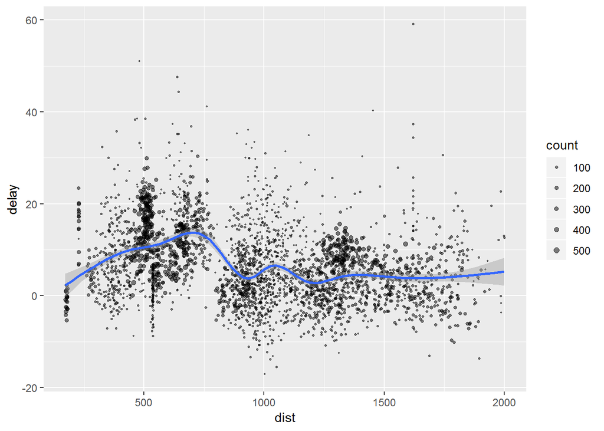

```r
library(ggplot2)
ggplot(delay, aes(dist, delay)) +
  geom_point(aes(size = count), alpha = 1/2) +
  geom_smooth() +
  scale_size_area(max_size = 2)
```

## Machine Learning sous Spark.

Beaucoup de méthodes de machine Leanring sont codées pour spark. Elles sont listées ici https://spark.rstudio.com/mlib/.

```r
mtcars_tbl <- copy_to(sc, mtcars)
# transform our data set, and then partition into 'training', 'test'
partitions <- mtcars_tbl %>%
  filter(hp >= 100) %>%
  mutate(cyl8 = cyl == 8) %>%
  sdf_random_split(training = 0.5, test = 0.5, seed = 1099)
```

Tout est dans `sc` tant qu’on n’a pas utilisé `collect`.  
On ajuste maintenant un modèle linéaire sur le Spark. Les fonctions s’appellent `ml_***`.

```r
fit <- partitions$training %>%
  ml_linear_regression(response = "mpg", features = c("wt", "cyl"))
fit
```

```
## Formula: mpg ~ wt + cyl
##
## Coefficients:
## (Intercept)          wt         cyl
##   33.499452   -2.818463   -0.923187
```

`fit` est un objet dans l’environnement de R. Les objets légers (estimation..) sont bien dans l’environnement. Par contre les choses lourdes (prédiction, données) restent sur `sc`.

```r
summary(fit)
```

```
## Deviance Residuals:
##    Min     1Q Median     3Q    Max
## -1.752 -1.134 -0.499  1.296  2.282
##
## Coefficients:
## (Intercept)          wt         cyl
##   33.499452   -2.818463   -0.923187
##
## R-Squared: 0.8274
## Root Mean Squared Error: 1.422
```